# ResNet

```python
import torch
from torch import nn
from torch.utils.data import DataLoader

import torchvision
from torchvision import datasets
from torchvision import transforms

import os
import random
import PIL
from PIL import Image
import numpy as np
import matplotlib.pyplot as plt
from tqdm import tqdm
```

```python
print(f"Using torch version {torch.__version__}.")
print(f"Using torchvision version {torchvision.__version__}.")
```

```
Using torch version 2.0.0.
Using torchvision version 0.15.0.
```

```python
device = 'cuda' if torch.cuda.is_available() else 'cpu'
print(f"Using {device}.")
```

```
Using cuda.
```

# Implementation of ResNet, first described in the paper "Deep Residual Learning for Image Recognition" by Kaiming He, Xiangyu Zhang, Shaoqing Ren, and Jian Sun.

## Prerequisites

- Intermediate Python programming. Basic understanding of neural networks and CNNs.
- Basic understanding of Pytorch or Tensorflow is helpful.
- It doesn't really matter what dataset you are using for the purposes of this tutorial.
  - We will build both the original-sized ResNets as well as a tiny version.
  - This will allow you to build and train the network from scratch, even with low compute power.
  - A small dataset sufficient to train the tiny version is available in the tutorial's repo.
  - If you want to train the full versions from the paper, you'll need to find a larger dataset.

## Overview of ResNet:

- ResNet is a Convolutional Neural Network designed for multiclass image classification tasks.
- ResNet was a major breakthrough, so it is worth replicating to understand.
- ResNet introduced and popularized "residual connections."
- The paper shows that residual connections should produce the same result but simplify training.
- The paper ultimately showed how to train deeper networks than previously possible.

## Step 1: Creating image transforms

- We need images to be prepared before we can use them in the model.
- It is best to create a replicable series of transformations for this.
- This allows images to quickly and easily be changed into a standard format for the model.

### What do the authors say?

Regarding input images, the authors say "[t]he image is resized with its shorter side randomly sampled in [256, 480] for scale augmentation. A 224x224 crop is randomly sampled from an image or its horizontal flip, with the per-pixel mean subtracted. The standard color augmentation in [ImageNet Classification with Deep Convolutional Neural Networks] is used." See section "3.4 Implementation" of the paper on page 4.

### Interpretation:

We will create a transform based on these instructions.

Multistep transforms are easy to build in Pytorch. We can build a list of these five transforms using Pytorch functions from torchvision.transforms. Then we can pass the list to transforms.Compose to create a single function that will pass an image through all five steps.

```python
# Create a transform similar to that described in ResNet paper
# Note that the contents of "Normalize" is the typical way to normalize
# ImageNet images. There is nothing magical about those numbers.

five_transforms = [transforms.Resize(size=(256, 256)),
                   transforms.ToTensor(),
                   transforms.Normalize((0.485, 0.456, 0.406),
                                        (0.229, 0.224, 0.225)),
                   transforms.RandomHorizontalFlip(p=0.5),
                   transforms.RandomCrop(size=(224, 224))
                  ]
resnet_transform = transforms.Compose(five_transforms)
```

But that transform is only for training. The transform for testing should imitate something we might use for real images. We would not randomly crop an image outside of a training environment, and the paper suggests that the image instead be center cropped for validation. We can make a second similar transform for validation. If this went into production, we would also remove the random flip, but we will keep it here.

```python
validation_transforms = [transforms.Resize(size=(256, 256)),
                         transforms.ToTensor(),
                         transforms.Normalize((0.485, 0.456, 0.406),
                                              (0.229, 0.224, 0.225)),
                         transforms.RandomHorizontalFlip(p=0.5),
                         transforms.CenterCrop(size=(224, 224))
                        ]
validation_transform = transforms.Compose(validation_transforms)
```

We've set up the transform. Now to check it, let's load an image from wherever the training data is located. I have most of the ImageNet 1M images on a local data-drive. You will need to fill in the absolute path to your own folder of images. Below, I'm using the n01614925 folder, which is a folder from ImageNet1K full of eagle images.

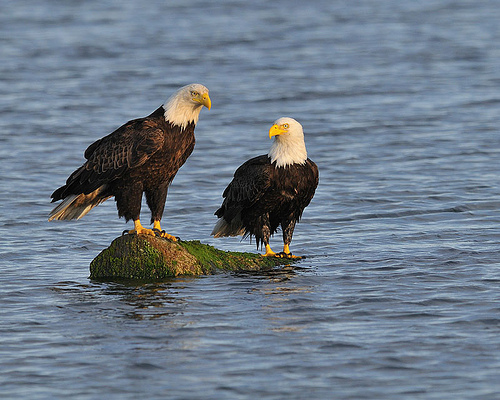

```python
# Grab a training image for debugging to ensure that the transform is working
path = r'/media/alexander/DATA-DRIVE/Data/imagenet/train/n01614925/'
img_path = path + random.sample(list(os.listdir(path)), 1)[0]
random_img = Image.open(img_path)
random_img
```

A fine eagle.

Below, we can write a simple helper function to describe an image's size and show the image. Note that a Pytorch tensor image's dimensions are (channels, height, width), whereas most other software uses (height, width, channels). This is the reason for the permutations when we are converting between Pytorch image tensors and Numpy to plot the image

```python
def describe_image(img):
    """Print image path (outside function scope) and dimensions."""

    # Check if the image is a PIL Jpeg. If so, print the information.
    if type(img) is PIL.JpegImagePlugin.JpegImageFile:
        print(f"Image path: {img_path}.")
        print(f"Image size: {img.height}, {img.width} (h x w)")
        plt.imshow(img)

    # Assumption! If the image is not a PIL, then here we assume that it has already
    # been converted to a tensor. Therefore we permute the dimensions back to match
    # a raw image's dimensions, send it to NumPy, and print the information.
    else:
        img = img.permute(1, 2, 0).numpy()
        print(f"Image path: {img_path}.")
        print(f"Image size: {img.shape[0]}, {img.shape[1]} (h x w)")
        plt.imshow(img)
```

```
Image path: /media/alexander/DATA-DRIVE/Data/imagenet/train/n01614925/n01614925_9594.JPEG.
Image size: 400, 500 (h x w)
```

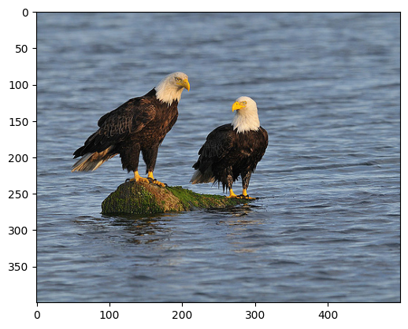

```python
# The image so far is not a tensor, it's just an image loaded with PIL.
# This should print the path on one line then the image dimensions on the next line.
describe_image(random_img)
```

Now, we are going to pass the image through the transform sequence that we defined above. After being transformed, when we pass it into the describe_image() function, the function should now tell us that the dimensions are 224x224 instead of the original dimensions. The color should also change, and it may end up flipped and cropped.

```python
# Transform the image then check again what the dimensions are.
# Matplotlib will complain about the RGB range. This is expected, don't worry.
transformed_img = resnet_transform(random_img)
```

[output not shown]

[output not shown]

[figure not shown]

```python
describe_image(transformed_img)
```

The transform is clearly working--we can see that the image has been resized certainly, the color has changed due to the normalization, and you may notice a flip or a crop.

Note: the color will probably look strange, and matplotlib will give a warning about clipping input data. This is because the transform changed the color channel values to a range that is not supported by matplotlib. This makes it look odd when we plot the image, but it has no impact on training the network.

## Step 2. Creating datasets and DataLoaders

- We need a way to load the data
- Pytorch has a prebuild object, ImageFolder, that facilitates this easily.

### Example of how Pytorch ImageFolder works:

Suppose I have a folder called "train" and inside of "train" I have three more folders called "dog", "cat", and "bird", each of which contain images of their respective animal. By instantiating a dataset.ImageFolder object with the root set to "train", Pytorch will automatically consider "dog", "cat", and "bird" folders to hold images, and it will further automatically consider the labels of images in those folder to be "dog", "cat", and "bird", respectively.

- We can also include our transform as an argument to the "transform" parameter, which results in our transform being automatically applied to the images in the dataset.
- This gives us an easy way to handle image data for network traiing.

```python
# Create dataset objects
train_data = datasets.ImageFolder(root=r'/media/alexander/DATA-DRIVE/Data/imagenet/train',
                                  transform=resnet_transform,
                                  #target_transform=None,
                                 )
test_data = datasets.ImageFolder(root=r'/media/alexander/DATA-DRIVE/Data/imagenet/val',
                                transform=validation_transform,
                               )
train_data, test_data
```

```
(Dataset ImageFolder
     Number of datapoints: 1217165
     Root location: /media/alexander/DATA-DRIVE/Data/imagenet/train
     StandardTransform
 Transform: Compose(
                Resize(size=(256, 256), interpolation=bilinear, max_size=None, antialias=warn)
                ToTensor()
                Normalize(mean=(0.485, 0.456, 0.406), std=(0.229, 0.224, 0.225))
                RandomHorizontalFlip(p=0.5)
                RandomCrop(size=(224, 224), padding=None)
            ),
 Dataset ImageFolder
     Number of datapoints: 64002
     Root location: /media/alexander/DATA-DRIVE/Data/imagenet/val
     StandardTransform
 Transform: Compose(
                Resize(size=(256, 256), interpolation=bilinear, max_size=None, antialias=warn)
                ToTensor()
                Normalize(mean=(0.485, 0.456, 0.406), std=(0.229, 0.224, 0.225))
                RandomHorizontalFlip(p=0.5)
                CenterCrop(size=(224, 224))
            ))
```

Now, we will create DataLoaders. Dataloaders take the dataset that we just created as well as the batch size we'd like to use, the number of workers (cpu cores) used for processes, and whether the data should be shuffled. The original paper used a batch size of 256, and we will stick with that here.

Note: If you're following this tutorial using a smaller dataset, plan to train the tiny version, or have limited CPU/GPU memory, you are free to choose a much smaller batch size.

```python
# Create dataloaders
# Original paper used a batch size of 256.
BATCH_SIZE = 256
train_dataloader = DataLoader(dataset=train_data,
                              batch_size=BATCH_SIZE,
                              num_workers=os.cpu_count(),
                              shuffle=True,
                             )

test_dataloader = DataLoader(dataset=test_data,
                             batch_size=BATCH_SIZE,
                             num_workers=os.cpu_count(),
                             shuffle=False,
                            )
train_dataloader, test_dataloader
```

```
(<torch.utils.data.dataloader.DataLoader at 0x7fd180e52710>,
 <torch.utils.data.dataloader.DataLoader at 0x7fd0b0045360>)
```

## Step 3. Code the Model Architecture

We have the data portions of the code prepared. Now we need to code the actual model architecture.

Model architectures are just a sequence of operations on data. If you understand what operations are being applied and what they are being applied on, then you can code the architecture.

In 3.4, the authors note that they "adopt batch normalization right after each convolution and before activation..." and we can see in Figure 2 that they're using ReLU activation for their residual blocks.

Figure 2 shows the "building block" of the network. If you look at figure 3 on page 4 of the paper, you can see a picture of a 34-layer residual network. There are multiple ways to implement any network, but I think that a simple way to implement this network is to notice that there are really only 3 different types of block, and by coding those 3 blocks, you can build the entire network pretty easily. By "block" I mean a sequence of layers that can be grouped together and viewed as a single unit. Here are the three blocks that I see:

1. The input block. This is comprised of a uniquely sized convolution that doesn't appear in the rest of the network as well as a pool (maxpool) layer that again does not occur in the rest of the network. There is no residual connection here.
2. The basic building blocks, as in figure 2. These consist of 3x3 conv -> ReLU -> 3x3 conv -> residual connection -> ReLU. Because the input and output are the same number of channels, we can create this block to accept a "channels" argument and use the same type of block repeatedly throughout the whole network.
3. The transition blocks. These are almost the same as the basic building blocks, except the output size is different from the input size, which requires some changes from the basic block. This can take arguments for in_channels and out_channels, and we will use 2D convolutions with a kernel size of 1 to modify the channels with our residual connection. This will be explained in more detail below. We will use this transition block whenever the number of channels changes in the network (the dashed lines in Figure 3).

The network ends with an avg pool before the output, but that is a lone generic avg pool layer. We don't need to code anything special for it, we can use the one provided by Pytorch nn.

### Step 3.1 Understand the Convolutional Operations

To be able to successfully implement the network, the main tripping point is how the image tensor's dimensions changes as it passes through each layer.

Reference Table 1 on page 4. This table gives details of the implementation of each block. Look at the first row in the table, corresponding to the first convolutional layer.

It says that the output size is 112x112. Then is also gives the information "7x7, 64, stride 2." This means The kernel size is 7x7, the number of output channels is 64, and the stride is 2. However, this is actually not sufficient to code the model in Pytorch--if you perform a 2D convolution on the initial image using those parameter, the output shape is *not* 112x112. This is because we need to include padding, but the paper does not explicitly mention the amount of padding anywhere.

Check the equation for the 2D Convolution operation in the Pytorch documentation, located at the bottom of this page: https://pytorch.org/docs/stable/generated/torch.nn.Conv2d.html. If you plug in the known variables, the equation becomes:

112 = ⌊(224 + (2×padding) − 6 − 1)/2 + 1⌋

112 = ⌊112 + padding − 3.5 + 1⌋

112 = ⌊109.5 + padding⌋

3 = padding

So we need to use padding=3 in the initial convolution operation.

Similarly, if we use a max pool layer with a kernel size of 3 and a stride of 2 as shown in row 2 of Table 1, the output is again wrong, and we again need to realize that we must adding padding=1.

Now we can implement the initial and basic blocks.

```python
class ResNet_initial_block(nn.Module):
    """
    Accept (batch_size, 3, 224, 224) shaped tensor and pass it through
    a 7x7 convolution and MaxPool layer.
    """
    def __init__(self):
        super().__init__()

        # The convolution, batchnorm, and ReLU activation.
        # Remember to add the padding!
        self.resnet_block1 = nn.Sequential(nn.Conv2d(in_channels=3,
                                                     out_channels=64,
                                                     kernel_size=(7, 7),
                                                     stride=2,
                                                     padding=3
                                                     ),
                                           nn.BatchNorm2d(64),
                                           nn.ReLU(),
                                          )

        # The Max Pool layer. Remember to add the padding!
        self.pool = nn.MaxPool2d(kernel_size=3,
                                 stride=2,
                                 padding=1,
                                )

    def forward(self, x):
        x = self.resnet_block1(x)
        x = self.pool(x)
        return x
```

```python
class ResNet_basic_block(nn.Module):
    """Accept tensors and do these operations: conv, relu, conv, add residual, relu."""
    def __init__(self,
                 channels: int):
        super().__init__()
        self.conv1 = nn.Sequential(nn.Conv2d(in_channels=channels,
                                             out_channels=channels,
                                             kernel_size=(3, 3),
                                             padding='same'
                                            ),
                                   nn.BatchNorm2d(channels),
                                   nn.ReLU()
                                  )

        self.conv2 = nn.Sequential(nn.Conv2d(in_channels=channels,
                                             out_channels=channels,
                                             kernel_size=(3, 3),
                                             padding='same'
                                            ),
                                   nn.BatchNorm2d(channels)
                                  )

        self.relu = nn.ReLU()

    def forward(self, x):
        res = x
        x = self.conv1(x)
        x = self.conv2(x)
        x += res
        return self.relu(x)
```

### Step 3.2 Residual Connection across different tensor sizes

When we code the transition block below, the size and number of channels of the output are different than the dimensions of the input, yet we need to add the input to the output as a residual connection. How can we accomplish this?

We can use a 2D Convolution with a kernel size of 1 and a stride of 2 to downsample the residual to the same shape as the output.

```python
class ResNet_transition_block(nn.Module):
    """Accept tensors and do these operations: conv, relu, conv, add residual, relu."""
    def __init__(self,
                 in_channels: int,
                 out_channels: int):
        super().__init__()
        self.conv1 = nn.Sequential(nn.Conv2d(in_channels=in_channels,
                                             out_channels=out_channels,
                                             kernel_size=(3, 3),
                                             stride=2,
                                             padding=1
                                            ),
                                   nn.BatchNorm2d(out_channels),
                                   nn.ReLU()
                                  )

        self.conv2 = nn.Sequential(nn.Conv2d(in_channels=out_channels,
                                             out_channels=out_channels,
                                             kernel_size=(3, 3),
                                             padding='same'
                                            ),
                                   nn.BatchNorm2d(out_channels)
                                  )

        #
        self.residual = nn.Conv2d(in_channels=in_channels,
                                  out_channels=out_channels,
                                  kernel_size=(1, 1),
                                  stride=2
                                 )

        self.relu = nn.ReLU()

    def forward(self, x):
        res = self.residual(x)
        x = self.conv1(x)
        x = self.conv2(x)
        x += res
        return self.relu(x)
```

### Step 3.3 Test the Blocks

It is best to test layers and blocks as they are built. This will likely include adding print statements to observe how the dimensions of the input change as it passes through different layers. This can help a lot with debugging.

We can test the three blocks above by instantiating one copy of each and noting what the expected output dimensions are, then passing an image through the blocks and observing whether it passes through without error and with the expected dimensions.

```python
# Let's test the three types of blocks before assembling a model.
initial_block_test = ResNet_initial_block()
basic_block_test = ResNet_basic_block(64)
transition_block_test = ResNet_transition_block(64, 128)
```

```python
# Before putting together the model, pass an image through an example of each layer to check for bugs
transformed_img = resnet_transform(random_img).unsqueeze(dim=0)
initial_output = initial_block_test(transformed_img)
basic_output = basic_block_test(initial_output)
transition_output = transition_block_test(basic_output)

# Should be (1 x 64 x 56 x 56)
print(f"Initial output shape: {initial_output.shape}")
# Should be (1 x 64 x 56 x 56)
print(f"Basic output shape: {basic_output.shape}")
# Should be (1 x 128 x 28 x 28)
print(f"Transition output shape: {transition_output.shape}")
```

```
Initial output shape: torch.Size([1, 64, 56, 56])
Basic output shape: torch.Size([1, 64, 56, 56])
Transition output shape: torch.Size([1, 128, 28, 28])
```

### Step 3.4 Put the Pieces Together

With the blocks made, we just need to put them together to create a network architecture. Below, I will create a micro version of ResNet that is powerful enough to get decent results on very simple tasks, like binary image classification. Then I will also implement ResNet-18 and ResNet-34 as shown in the paper.

The paper also includes 50-, 101-, and 152-layer versions. I will not make those versions here. If you want to make those versions, you can create one more block, the "bottleneck" block, which can be built fairly easily using the kernel with size 1 trick that was used to make residual connection work in the transition block.

One further note is that if we had a goal of making a generalizable ResNet architecture, we would make a single more detailed model class that users could customize by passing in details as arguments, like number of layers, and get back different sizes and flavors of ResNet for their application. Since our goal is instead paper replication for practice, we're only going to implement the 18- and 34- layer networks that are specifically presented and discussed in the paper. The only modification I make is that the user can pass in the number of classes in case you want to try training one of these networks on something other than the dataset used in the paper.

```python
class ResNetMicro(nn.Module):
    """A miniaturized version of ResNet. This version is not present in the paper,
    but is included here so that anyone following along will be able to train a working
    network from scratch without needing a huge dataset and powerful GPU accelerator.

    If you want to train a basic ResNet for binary classification, you can try this.
    """

    def __init__(self, classes=2) -> None:
        # Set classes = to number of classes in your data. By default assumes binary.
        super().__init__()

        self.resnetmicro = nn.Sequential(*[
        ResNet_initial_block(),
        ResNet_transition_block(64, 128),
        ResNet_transition_block(128, 256),
        ResNet_transition_block(256, 512),
        nn.AvgPool2d(kernel_size=(7, 7)),
        nn.Flatten(),
        nn.Linear(in_features=512, out_features=classes)
        ])

    def forward(self, x):
        return self.resnetmicro(x)
```

```python
class ResNet18(nn.Module):
    """Model architecture based on the the paper 'Deep Residual Learning for Image Recognition'
       by He, Zhang, Ren, and Sun (2015).

       This is the 18-layer version.
       """

    def __init__(self, classes=1000) -> None:
        super().__init__()

        self.resnet18 = nn.Sequential(*[
        ResNet_initial_block(),
        nn.Sequential(*(ResNet_basic_block(64) for _ in range(2))),
        ResNet_transition_block(64, 128),
        nn.Sequential(*(ResNet_basic_block(128) for _ in range(1))),
        ResNet_transition_block(128, 256),
        nn.Sequential(*(ResNet_basic_block(256) for _ in range(1))),
        ResNet_transition_block(256, 512),
        nn.Sequential(*(ResNet_basic_block(512) for _ in range(1))),
        nn.AvgPool2d(kernel_size=(7, 7)),
        nn.Flatten(),
        nn.Linear(in_features=512, out_features=classes)
        ])

    def forward(self, x):
        return self.resnet18(x)
```

```python
class ResNet34(nn.Module):
    """Model architecture based on the the paper 'Deep Residual Learning for Image Recognition'
       by He, Zhang, Ren, and Sun (2015).

       This is the 34-layer version.
       """

    def __init__(self, classes=1000) -> None:
        super().__init__()

        self.resnet34 = nn.Sequential(*[
        ResNet_initial_block(),
        nn.Sequential(*(ResNet_basic_block(64) for _ in range(3))),
        ResNet_transition_block(64, 128),
        nn.Sequential(*(ResNet_basic_block(128) for _ in range(3))),
        ResNet_transition_block(128, 256),
        nn.Sequential(*(ResNet_basic_block(256) for _ in range(5))),
        ResNet_transition_block(256, 512),
        nn.Sequential(*(ResNet_basic_block(512) for _ in range(2))),
        nn.AvgPool2d(kernel_size=(7, 7)),
        nn.Flatten(),
        nn.Linear(in_features=512, out_features=classes)
        ])

    def forward(self, x):
        return self.resnet34(x)
```

## Step 4: Training

Below I define function for the training and testing loop. The comments explain the steps. I will not discuss it in detail since it is a fairly generic process--if you have ever trained or fine-tuned any neural network in Pytorch, the below code should seem familiar.

A minor note is that the train_step function accepts a result_dict. This will be used to monitor training per iteration instead of per epoch. The paper shows iterations as well instead of epochs in their plots of loss during training. This is because there is so much data that the jump in loss between epoch is likely to be large--the gradients are being updated hundreds of times and seeing over 1 million images per epoch.

```python
def train_step(model: torch.nn.Module,
               dataloader: torch.utils.data.DataLoader,
               loss_fn: torch.nn.Module,
               optimizer: torch.optim.Optimizer,
               device,
               result_dict=None,
              ):

    # Set the model to train mode
    model.train()

    # Set up the training loss and validation accuracy
    train_loss = 0
    train_acc = 0
    print("Training...")

    for batch, (X, y) in enumerate(tqdm(dataloader)):
        # Send the data to the target device
        X, y = X.to(device), y.to(device)

        # 1. Forward pass
        y_predictions = model(X)

        # 2. Calculate the loss
        loss = loss_fn(y_predictions, y)
        iter_loss = loss.item()
        train_loss += loss.item()

        # 3. Zero out the gradients
        optimizer.zero_grad()

        # 4. Backpropagation
        loss.backward()

        # 5. Update the parameters
        optimizer.step()

        # Calculate the accuracy metric
        y_prediction_classes = torch.argmax(torch.softmax(y_predictions, dim=1), dim=1)
        iter_acc = (y_prediction_classes == y).sum().item()/len(y_predictions)
        train_acc += (y_prediction_classes == y).sum().item()/len(y_predictions)

        if result_dict:
            result_dict['train_loss'].append(iter_loss)
            result_dict['train_acc'].append(iter_acc)

    # Adjust the metrics to be the per-batch averages
    train_loss /= len(dataloader)
    train_acc /= len(dataloader)

    return train_loss, train_acc
```

```python
def test_step(model: torch.nn.Module,
              dataloader: torch.utils.data.DataLoader,
              loss_fn: torch.nn.Module,
              device,
              ):

    # Set the model to evaluation mode
    model.eval()

    # Set up the validation loss and validation accuracy
    test_loss = 0
    test_acc = 0
    print("Testing...")

    with torch.inference_mode():
        for batch, (X, y) in enumerate(tqdm(dataloader)):
            # Send the data to the target device
            X, y = X.to(device), y.to(device)

            # 1. Forward pass
            y_predictions = model(X)

            # 2. Calculate the loss
            loss = loss_fn(y_predictions, y)
            test_loss += loss.item()

            # Calculate the accuracy metric
            y_prediction_classes = torch.argmax(torch.softmax(y_predictions, dim=1), dim=1)
            test_acc += (y_prediction_classes == y).sum().item()/len(y_predictions)

    # Adjust the metrics to be the per-batch averages
    test_loss /= len(dataloader)
    test_acc /= len(dataloader)

    return test_loss, test_acc
```

```python
# Set up the training
# Original paper used stochastic gradient descent with manually adjusted learning rate
# initialized at 0.001 and divided by 10 whenever error plateaus.
# Will use Adam here.


model = model = ResNet34().to(device)

lr = 0.001
optimizer = torch.optim.Adam(params=model.parameters(),
                             lr=lr
                            )

loss_fn = nn.CrossEntropyLoss()

# Create a dictionary of lists to store training results
epoch_results = {}
epoch_results['epoch'] = []
epoch_results['train_loss'] = []
epoch_results['train_acc'] = []
epoch_results['test_loss'] = []
epoch_results['test_acc'] = []
epoch_results['learning_rate'] = []

iter_results = {}
iter_results['train_loss'] = []
iter_results['train_acc'] = []
iter_results['test_loss'] = []
iter_results['test_acc'] = []
```

```python
# OPTIONAL: load the simpler data
train_data = datasets.ImageFolder(root=r'/yourpath/dogs_vs_cats/train',
                                  transform=resnet_transform,
                                 )
test_data = datasets.ImageFolder(root=r'/yourpath/dogs_vs_cats/validate',
                                 transform=validation_transform,
                                )

BATCH_SIZE = 128
train_dataloader = DataLoader(dataset=train_data,
                              batch_size=BATCH_SIZE,
                              num_workers=os.cpu_count(),
                              shuffle=True,
                             )

test_dataloader = DataLoader(dataset=test_data,
                             batch_size=BATCH_SIZE,
                             num_workers=os.cpu_count(),
                             shuffle=False,
                            )

# OPTIONAL: load the simpler model
model = ResNetMicro().to(device)
```

```python
# We can check how many parameters our model has like this
print(f"Model has {sum(p.numel() for p in model.parameters())} parameters.")
```

[output not shown]

```python
# Time to train

def run(model):
    """Run the model for one epoch."""

    train_loss, train_acc = train_step(model=model,
                                       dataloader=train_dataloader,
                                       loss_fn=loss_fn,
                                       optimizer=optimizer,
                                       device=device,
                                       result_dict=iter_results,
                                      )

    test_loss, test_acc = test_step(model=model,
                                    dataloader=test_dataloader,
                                    loss_fn=loss_fn,
                                    device=device,
                                   )

    epoch_results['train_loss'].append(train_loss)
    epoch_results['train_acc'].append(train_acc)
    epoch_results['test_loss'].append(test_loss)
    epoch_results['test_acc'].append(test_acc)
    epoch_results['learning_rate'].append(lr)

    print(f'| Train Accuracy: {train_acc:.3f} | Val Accuracy: {test_acc:.3f}')
    print(f'| Train Loss: {train_loss:.3f} | Val Loss: {test_loss:.3f} | LR: {lr}')
```

```python
# We'll train for 12 total epochs and see what happens.
# In the paper, the authors manually adjusted the LR after plateaus.
# Here, we'll adjust the learning rate automatically every 4 epochs.

for epoch in range(1, 13):
    run(model)
    if epoch % 4 == 0:
        lr /= 10
        optimizer = torch.optim.Adam(params=model.parameters(),
                                     lr=lr
                                    )
```

```
Training...
```

```
Testing...
```

```
| Train Accuracy: 0.122 | Val Accuracy: 0.245
| Train Loss: 4.821 | Val Loss: 3.676 | LR: 0.001
Training...
```

```
Testing...
```

```
| Train Accuracy: 0.344 | Val Accuracy: 0.384
| Train Loss: 3.037 | Val Loss: 2.820 | LR: 0.001
Training...
```

```
Testing...
```

```
| Train Accuracy: 0.455 | Val Accuracy: 0.451
| Train Loss: 2.397 | Val Loss: 2.428 | LR: 0.001
Training...
```

```
Testing...
```

```
| Train Accuracy: 0.520 | Val Accuracy: 0.494
| Train Loss: 2.049 | Val Loss: 2.207 | LR: 0.001
Training...
```

```
Testing...
```

```
| Train Accuracy: 0.617 | Val Accuracy: 0.592
| Train Loss: 1.588 | Val Loss: 1.712 | LR: 0.0001
Training...
```

```
Testing...
```

```
| Train Accuracy: 0.635 | Val Accuracy: 0.602
| Train Loss: 1.498 | Val Loss: 1.677 | LR: 0.0001
Training...
```

```
Testing...
```

```
| Train Accuracy: 0.645 | Val Accuracy: 0.606
| Train Loss: 1.448 | Val Loss: 1.659 | LR: 0.0001
Training...
```

```
Testing...
```

```
| Train Accuracy: 0.654 | Val Accuracy: 0.612
| Train Loss: 1.405 | Val Loss: 1.631 | LR: 0.0001
Training...
```

```
Testing...
```

```
| Train Accuracy: 0.668 | Val Accuracy: 0.619
| Train Loss: 1.343 | Val Loss: 1.602 | LR: 1e-05
Training...
```

```
Testing...
```

```
| Train Accuracy: 0.670 | Val Accuracy: 0.619
| Train Loss: 1.333 | Val Loss: 1.596 | LR: 1e-05
Training...
```

```
Testing...
```

```
| Train Accuracy: 0.671 | Val Accuracy: 0.620
| Train Loss: 1.327 | Val Loss: 1.593 | LR: 1e-05
Training...
```

```
Testing...
```

```
| Train Accuracy: 0.672 | Val Accuracy: 0.620
| Train Loss: 1.322 | Val Loss: 1.596 | LR: 1e-05
```

### Step 5: Assess Results

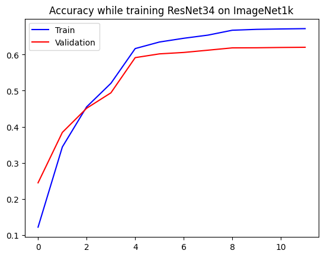

```python
plt.plot(epoch_results['train_acc'], c='b', label='Train')
plt.plot(epoch_results['test_acc'], c='r', label='Validation')
plt.title('Accuracy while training ResNet34 on ImageNet1k')
plt.legend()
plt.show()
```

## Final Notes

The ultimately accuracy of this model is not quite as high as the model in the paper. There are many possible reasons for this, including small differences in implmentation, frameworks used, details of training, and differences in data (my dataset in the above training is derived from ImageNet 1k, but not all of the images used by the authors are in my dataset).

You can improve results by tuning and tweaking the model. The goal here was not to make a highly optimized and tuned model, but to demonstrate how a model can be coded and trained in Pytorch from scratch when you only have a paper and some documentation to guide you.